# polySegratio: An R library for autopolyploid segregation analysis

# 2 Simulating a set of markers

Functions `sim.autoMarkers` and `sim.autoCross` may be used to simulate marker data for a collection of markers where either one of the parents is nulliplex or where both parents contain at least one dose of a marker. The data are only simulated to produce appropriate segregation ratios but other genetic parameters such as recombination, degree of preferential pairing or a genetic map are not considered. The proportions in each marker dosage need to be specified.

`sim.autoMarkers` may be used to simulate dominant markers from an autopolyploid cross given the ploidy level, specified parental marker alleles, the expected segregation ratios and the proportions in each dosage marker class. The ploidy level may be chosen from tetraploid to heccaidecaploid and the segregation ratios may be specified explicitly or generated automatically.

`sim.autoCross` is a wrapper to `sim.autoMarkers` which is used to generate markers for parents with markers that are 10, 01 or 11. The proportions of markers for each of these three parental types must be specified.

Both functions return S3 class objects (class `simAutoCross` and class `simAutoMarkers`) which have associated print and plot methods.

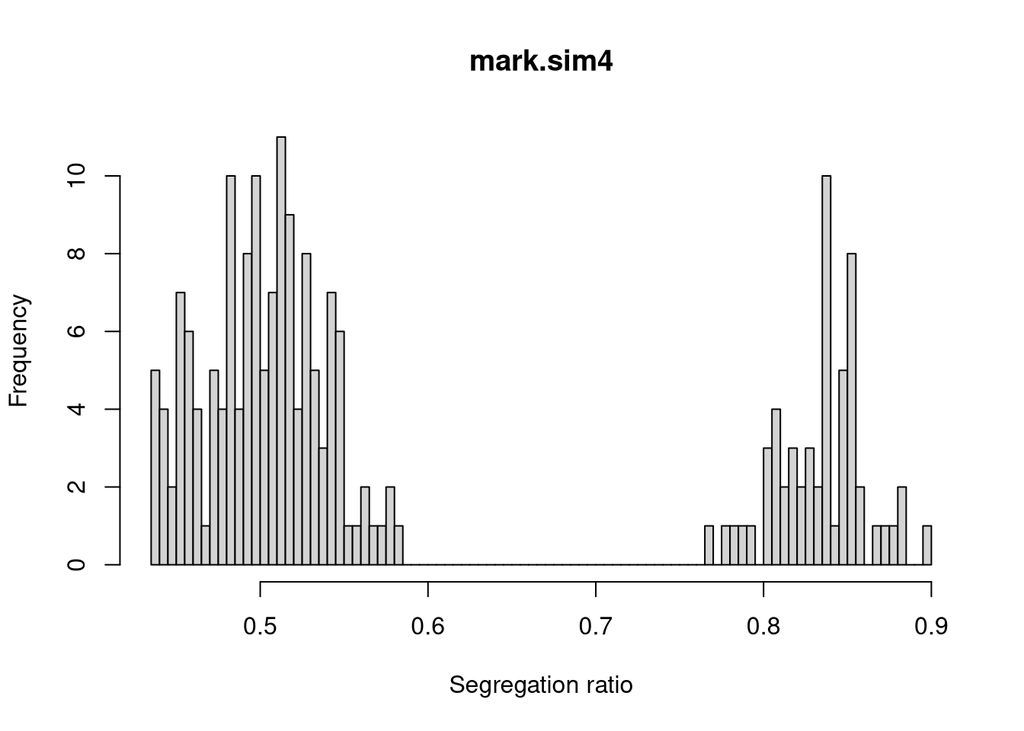

```r
mark.sim4 <- sim.autoMarkers(4, dose.proportion=c(0.7,0.3),
                             n.markers=200, n.individuals = 200)
print(mark.sim4)
#: Autopolyploid dominant markers generated at Thu Feb 26 00:07:55 2026
#: with call:
#: sim.autoMarkers(ploidy.level = 4, dose.proportion = c(0.7, 0.3),
#:     n.markers = 200, n.individuals = 200)
#:
#: Ploidy level is: 4 ( Tetraploid )
#: Parents were set as heterogeneous for the markers
#: Theoretical segregation proportions:
#:            ratio.SD            ratio.DD        ploidy.level
#:               "0.5" "0.833333333333333"                 "4"
#:         ploidy.name        type.parents
#:        "Tetraploid"     "heterogeneous"
#:
#: Proportions in each dosage class:
#:  SD  DD
#: 0.7 0.3
#: No. of markers generated from multinomial distribution:
#:    No.markers
#: SD        144
#: DD         56
#:
#: Data were generated for 200 individuals with 200 markers
#: A subset is:
#:      X.1 X.2 X.3 X.4 X.5 X.6 X.7 X.8 X.9 X.10 r   n   ratio dose
#: M.1  1   1   1   1   0   1   1   0   1   1    96  200 0.48  SD
#: M.2  0   1   0   0   1   1   0   1   0   1    106 200 0.53  SD
#: M.3  0   1   1   1   1   1   0   0   1   1    95  200 0.475 SD
#: M.4  1   0   1   1   1   0   0   1   0   0    103 200 0.515 SD
#: M.5  1   0   1   1   0   0   1   1   1   1    91  200 0.455 SD
#: M.6  0   1   1   0   0   1   1   0   1   1    104 200 0.52  SD
#: M.7  0   1   1   0   1   0   1   0   0   0    101 200 0.505 SD
#: M.8  1   0   1   1   1   0   1   1   1   0    103 200 0.515 SD
#: M.9  1   1   0   1   1   0   0   1   0   0    109 200 0.545 SD
#: M.10 0   0   0   1   0   1   1   0   1   0    99  200 0.495 SD
```

Figure 2.1 shows a histogram of segregation proportions for a tetraploid cross produced with `plot(mark.sim4)`. Other plots, may be produced. For instance, the number of missing values is useful when looking at real data to determine if some markers are not well measured (See Figure 2.2).

Often in molecular marker studies, a small percentage of markers may be missing or misclassified. The functions `addMissing` and `addMisclass` allow marker data to be modified accordingly. The rate may be specified either as a proportion of missing at random or a proportion of columns and rows with specified proportions of missings or misclassified. Not that if markers are randomly misclassified then the expected segregations ratios are still the same and so we may not expect to see much difference to perfectly classified markers.

Function `addMissing` adds missing data at random to objects of class `autoMarker` or `autoCross`. Function `addMisclass` misclassifies marker data in objects of class `autoMarker` or `autoCross` at a specified rate. Parental marker data may also be misclassified. An example might be

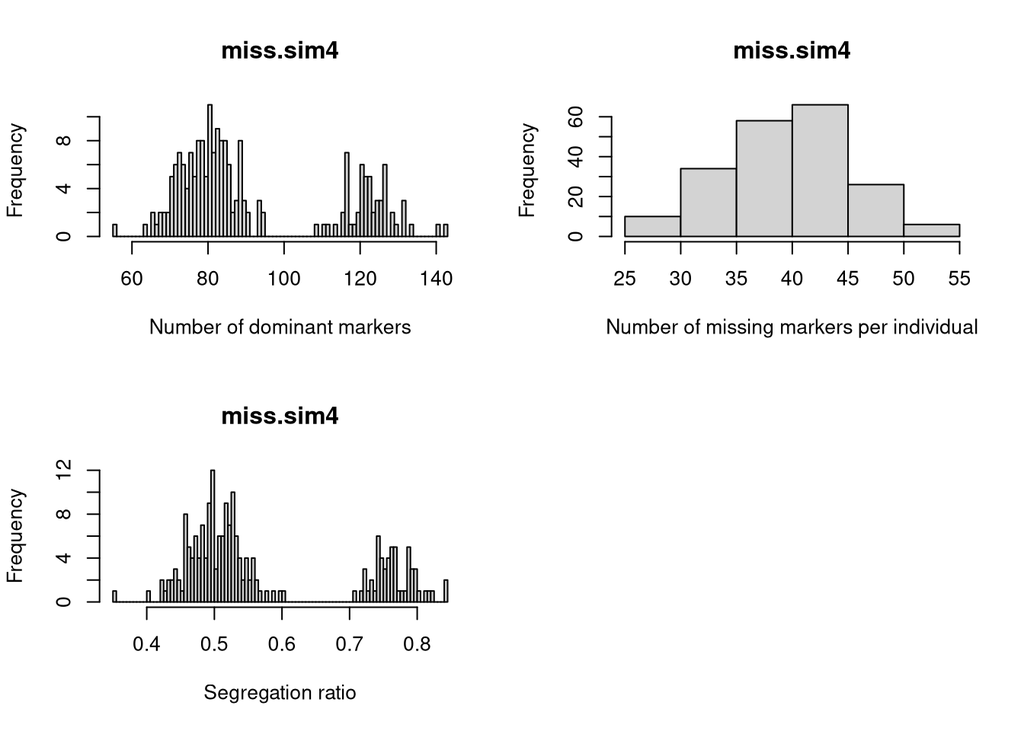

```r
miss.sim4 <- addMisclass(mark.sim4, misclass = 0.1)
miss.sim4 <- addMissing(miss.sim4, na.proportion = 0.2)
print(miss.sim4, col=c(1:6))
#: Autopolyploid dominant markers generated at Thu Feb 26 00:07:55 2026
#: with call:
#: sim.autoMarkers(ploidy.level = 4, dose.proportion = c(0.7, 0.3),
#:     n.markers = 200, n.individuals = 200)
#:
#: Ploidy level is: 4 ( Tetraploid )
#: Parents were set as heterogeneous for the markers
#: Theoretical segregation proportions:
#:            ratio.SD            ratio.DD        ploidy.level
#:               "0.5" "0.833333333333333"                 "4"
#:         ploidy.name        type.parents
#:        "Tetraploid"     "heterogeneous"
#:
#: Proportions in each dosage class:
#:  SD  DD
#: 0.7 0.3
#: No. of markers generated from multinomial distribution:
#:    No.markers
#: SD        144
#: DD         56
#:
#: Data were generated for 200 individuals with 200 markers
#: A subset is:
#:      X.1  X.2  X.3  X.4  X.5  X.6  X.7  X.8  X.9  X.10 r  n
#: M.1  1    <NA> 1    1    0    1    1    <NA> 1    1    72 152
#: M.2  0    1    0    0    <NA> 1    <NA> 0    0    1    85 164
#: M.3  0    1    0    0    1    1    <NA> 1    <NA> <NA> 68 156
#: M.4  1    0    1    1    0    0    0    1    0    0    86 163
#: M.5  1    <NA> 1    1    0    1    1    1    <NA> 1    78 159
#: M.6  <NA> <NA> 1    <NA> 0    1    <NA> 0    <NA> 1    86 167
#: M.7  0    1    <NA> <NA> <NA> 0    <NA> 0    0    0    77 158
#: M.8  0    0    1    0    <NA> 0    1    1    <NA> 0    78 157
#: M.9  0    1    0    1    1    <NA> 0    1    0    0    88 162
#: M.10 <NA> 1    0    <NA> <NA> 1    <NA> 0    1    0    74 156
#:      ratio             dose
#: M.1  0.473684210526316 SD
#: M.2  0.518292682926829 SD
#: M.3  0.435897435897436 SD
#: M.4  0.52760736196319  SD
#: M.5  0.490566037735849 SD
#: M.6  0.514970059880239 SD
#: M.7  0.487341772151899 SD
#: M.8  0.496815286624204 SD
#: M.9  0.54320987654321  SD
#: M.10 0.474358974358974 SD
#: Missing data generated for 20 % markers at random
```

Note that Figure 2.2 is produced with `plot(miss.sim4, type = "all")`.

## 2.1 Overdispersion

Since markers are correlated and may be subject to different types of measurement errors, then the segregation ratios may follow an overdispersed Binomial distribution. Such markers may be simulated with `sim.autoMarkers` by setting the parameter `overdispersion` to `TRUE`. The amount of overdispersion or extra–binomial variation may be specified by setting the `shape1` parameter. Larger values imply less overdispersion. Typically, the `R` command would be like `{sim.autoMarkers(4,c(0.8,0.2), overdisp=TRUE, shape1=20)`.

Overdispersed marker data are simulated from the Beta–Binomial distribution where the Binomial proportion $p$ is generated from a Beta distribution. Note that if $p$ is generated from a $\beta(a,b)$ distribution, then $E(p)=a/(a+b)$ and Var$(p)=ab/((a+b)^2(a+b+1))$. Thus constraining $E(p)$ to be the appropriate segregation proportion and setting the first shape parameter $a$ implies that $b = a(1-p)/p$. Tetraploid marker data generated for a range of `shape1` or $a$ values is shown in Figure 2.3.

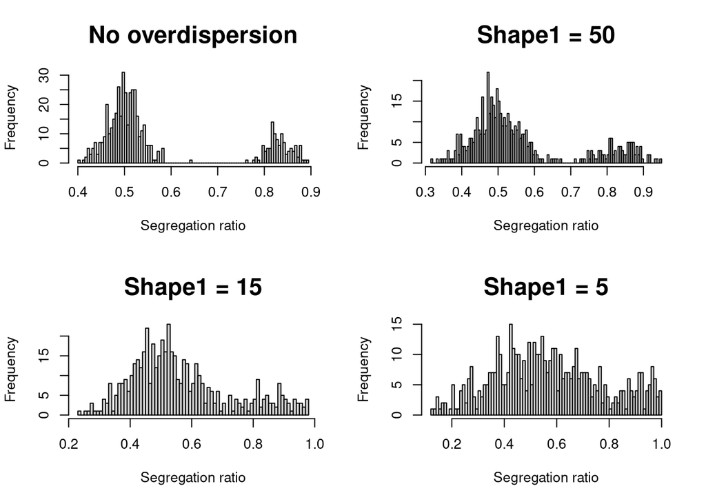

# 3 Standard approaches for assessing marker dosage

The most widely used test for assessing marker dosage is the standard $\chi^2$ test. Following Mather (1951), this test is often employed to compare the observed segregation ratio against its expected value. More recently, Ripol et al. (1999) proposed that the observed segregation proportion be compared to the appropriate Binomial confidence interval given the sample size and the expected segregation proportion.

Both tests may be carried out by means of the function `test.segRatio`. Note that if the tests reveal that a marker may be more than one dosage then it is not allocated a marker dosage.

## 3.1 $\chi^2$ tests

The default method of assessing marker dosage in `test.segRatio` is the $\chi^2$ test. The function requires that the segregation proportions are given in the form of object of S3 class `segRatio`. These are automatically produced for simulated data created with functions `sim.autoMarkers` and `sim.autoCross` and may be calculated from observed marker data either manually or by applying `segregationRatios` to a matrix of observed marker data.

For instance, to calculate $\chi^2$ tests, and allocate dosage for an autooctoploid then

```r
## simulated data
a <- sim.autoMarkers(ploidy = 8, c(0.7,0.2,0.09,0.01), n.markers=200,
                     n.individuals=100)
print(a)
#: Autopolyploid dominant markers generated at Thu Feb 26 00:07:56 2026
#: with call:
#: sim.autoMarkers(ploidy.level = 8, dose.proportion = c(0.7, 0.2,
#:     0.09, 0.01), n.markers = 200, n.individuals = 100)
#:
#: Ploidy level is: 8 ( Octaploid )
#: Parents were set as heterogeneous for the markers
#: Theoretical segregation proportions:
#:            ratio.SD            ratio.DD            ratio.TD
#:               "0.5" "0.785714285714286" "0.928571428571429"
#:            ratio.QD        ploidy.level         ploidy.name
#: "0.985714285714286"                 "8"         "Octaploid"
#:        type.parents
#:     "heterogeneous"
#:
#: Proportions in each dosage class:
#:   SD   DD   TD   QD
#: 0.70 0.20 0.09 0.01
#: No. of markers generated from multinomial distribution:
#:    No.markers
#: SD        137
#: DD         40
#: TD         21
#: QD          2
#:
#: Data were generated for 100 individuals with 200 markers
#: A subset is:
#:      X.1 X.2 X.3 X.4 X.5 X.6 X.7 X.8 X.9 X.10 r  n   ratio dose
#: M.1  0   1   1   0   1   0   1   1   1   1    50 100 0.5   SD
#: M.2  0   1   1   0   0   1   1   1   0   1    63 100 0.63  SD
#: M.3  1   1   1   1   0   0   1   1   1   0    59 100 0.59  SD
#: M.4  0   1   0   1   1   0   1   0   1   0    48 100 0.48  SD
#: M.5  1   0   0   0   1   0   0   0   0   1    44 100 0.44  SD
#: M.6  1   0   0   0   1   0   0   0   1   1    46 100 0.46  SD
#: M.7  0   1   0   0   0   1   0   0   1   0    46 100 0.46  SD
#: M.8  0   1   1   0   1   1   0   1   0   0    51 100 0.51  SD
#: M.9  0   1   0   1   1   0   0   1   1   1    52 100 0.52  SD
#: M.10 1   0   1   1   0   0   0   0   1   1    57 100 0.57  SD
```

```r
## summarise chi-squared test vs true
ac <- test.segRatio(a$seg.ratios, ploidy=8, method="chi.squared")
print(ac)
#: Segregation ratio test:
#: Method: chi.squared at the 0.05 level
#: Expected segregation ratios:
#:            ratio.SD            ratio.DD            ratio.TD
#:               "0.5" "0.785714285714286" "0.928571428571429"
#:            ratio.QD        ploidy.level         ploidy.name
#: "0.985714285714286"                 "8"         "Octaploid"
#:        type.parents
#:     "heterogeneous"
#: Proportion of markers classified at 0.05 level: 0.97
#: Classified: 194 , not classified: 6
#: Markers doubly classified: 1
#: M.196
#: SD DD TD QD
#:  0  0  1  1
#: Number in each marker dosage class (classified once):
#:  SD  DD  TD  QD
#: 132  41  18   3
#: Dosage of first 10 markers (where dosage unique):
#:  M.1  M.2  M.3  M.4  M.5  M.6  M.7  M.8  M.9 M.10
#:    1   NA    1    1    1    1    1    1    1    1
#: Call: test.segRatio(seg.ratio = a$seg.ratios, ploidy.level = 8, method = "chi.squared")
print(addmargins(table(a$true.doses$dosage, ac$dosage, exclude=NULL)))
#:
#:         1   2   3   4 <NA> Sum
#:   1   132   0   0   0    5 137
#:   2     0  40   0   0    0  40
#:   3     0   1  18   1    1  21
#:   4     0   0   0   2    0   2
#:   Sum 132  41  18   3    6 200
```

Note that for segregation ratios near to one the $\chi^2$ approximation may not hold and so `R` will produce a warning.

## 3.2 Binomial confidence intervals

The Binomial confidence interval approach of Ripol et al. (1999) is obtained by setting the `method` parameter to `binomial`. The $\alpha$ level may be set in either method by setting the parameter `alpha`. For instance,

```r
## summarise binomial CI vs true
ab <- test.segRatio(a$seg.ratios, ploidy=8, method="bin", alpha=0.01)
print(ab)
#: Segregation ratio test:
#: Method: binomial at the 0.01 level
#: Expected segregation ratios:
#:            ratio.SD            ratio.DD            ratio.TD
#:               "0.5" "0.785714285714286" "0.928571428571429"
#:            ratio.QD        ploidy.level         ploidy.name
#: "0.985714285714286"                 "8"         "Octaploid"
#:        type.parents
#:     "heterogeneous"
#: Proportion of markers classified at 0.01 level: 0.95
#: Classified: 190 , not classified: 10
#: Markers doubly classified: 6
#:       SD DD TD QD
#: M.152  0  1  1  0
#: M.178  0  1  1  0
#: M.181  0  0  1  1
#: M.184  0  0  1  1
#: M.185  0  0  1  1
#: M.196  0  0  1  1
#: Number in each marker dosage class (classified once):
#:  SD  DD  TD  QD
#: 133  39  16   2
#: Dosage of first 10 markers (where dosage unique):
#:  M.1  M.2  M.3  M.4  M.5  M.6  M.7  M.8  M.9 M.10
#:    1   NA    1    1    1    1    1    1    1    1
#: Call: test.segRatio(seg.ratio = a$seg.ratios, ploidy.level = 8, method = "bin",
#:     alpha = 0.01)
print(addmargins(table(a$true.doses$dosage, ab$dosage, exclude=NULL)))
#:
#:         1   2   3   4 <NA> Sum
#:   1   133   0   0   0    4 137
#:   2     0  39   0   0    1  40
#:   3     0   0  16   0    5  21
#:   4     0   0   0   2    0   2
#:   Sum 133  39  16   2   10 200
```

# 4 Utility functions

Several utility functions are included for use with real or simulated data.

When marker data are stored in spreadsheets repetitive parts of marker names may be left blank or columns containing parts of names may need to be combined. To aid the process of constructing unique marker labels, `autoFill` automatically fills out blanks of a vector with the preceding label and `makeLabel` generates labels from two columns where blanks in first column are replaced by preceding non-blank label.

```r
## imaginary data frame representing ceq marker names read in from
## spreadsheet
x <- data.frame( col1 = c("agc","","","","gct5","","ccc","",""),
                col2 = c(1,3,4,5,1,2,2,4,6))
print(x)
#:   col1 col2
#: 1  agc    1
#: 2         3
#: 3         4
#: 4         5
#: 5 gct5    1
#: 6         2
#: 7  ccc    2
#: 8         4
#: 9         6
print(makeLabel(x))
#: [1] "agc1"  "agc3"  "agc4"  "agc5"  "gct51" "gct52" "ccc2"  "ccc4"
#: [9] "ccc6"
print(cbind(x,lab=makeLabel(x, sep=".")))
#:   col1 col2    lab
#: 1  agc    1  agc.1
#: 2         3  agc.3
#: 3         4  agc.4
#: 4         5  agc.5
#: 5 gct5    1 gct5.1
#: 6         2 gct5.2
#: 7  ccc    2  ccc.2
#: 8         4  ccc.4
#: 9         6  ccc.6
```

Function `divide.autoMarkers` will split up a set of markers depending on the parental alleles. This is useful when extracting markers to be used in constructing a marker map for one parent say or in obtaining those markers present in both parents but segregating in the offspring.

```r
p2 <- sim.autoCross(4,
dose.proportion=list(p01=c(0.7,0.3),p10=c(0.7,0.3),
                     p11=c(0.6,0.2,0.2)))
print(p2, row=c(1:5))
#: Autopolyploid dominant markers for crosses generated at Thu Feb 26 00:07:56 2026
#: with call:
#: sim.autoCross(ploidy.level = 4, dose.proportion = list(p01 = c(0.7,
#:     0.3), p10 = c(0.7, 0.3), p11 = c(0.6, 0.2, 0.2)))
#:
#: Ploidy level is: 4 ( Tetraploid )
#: The proportion of markers of each parental type were
#: p10 p01 p11
#: 0.4 0.4 0.2
#: Theoretical segregation proportions:
#: p10:
#:            ratio.SD            ratio.DD        ploidy.level
#:               "0.5" "0.833333333333333"                 "4"
#:         ploidy.name        type.parents
#:        "Tetraploid"     "heterogeneous"
#: p01:
#:            ratio.SD            ratio.DD        ploidy.level
#:               "0.5" "0.833333333333333"                 "4"
#:         ploidy.name        type.parents
#:        "Tetraploid"     "heterogeneous"
#: p11:
#:         ratio.SDxSD         ratio.SDxDD         ratio.DDxDD
#:              "0.75" "0.916666666666667" "0.972222222222222"
#:        ploidy.level         ploidy.name        type.parents
#:                 "4"        "Tetraploid"        "homozygous"
#:
#: Proportions in each dosage class:
#: p10:
#:  SD  DD
#: 0.7 0.3
#: p01:
#:  SD  DD
#: 0.7 0.3
#: p11:
#: SDxSD SDxDD DDxDD
#:   0.6   0.2   0.2
#: No. of markers generated from multinomial distribution:
#: p10:
#:    No.markers
#: SD        131
#: DD         60
#: p01:
#:    No.markers
#: SD        137
#: DD         64
#: p11:
#:       No.markers
#: SDxSD         70
#: SDxDD         24
#: DDxDD         14
#:
#: Overall: data were generated for 200 individuals with 500 markers
#: A subset is:
#:      P.1 P.2 X.1 X.2 X.3 X.4 X.5 X.6 X.7 X.8 r   n   ratio dose
#: M.1  1   0   1   1   0   1   1   0   0   0   88  200 0.44  SD
#: M.2  1   0   1   1   1   0   1   0   1   0   96  200 0.48  SD
#: M.3  1   0   1   0   1   1   0   0   0   1   95  200 0.475 SD
#: M.4  1   0   1   1   0   1   0   1   0   1   95  200 0.475 SD
#: M.5  1   0   0   1   0   1   1   1   0   0   102 200 0.51  SD
#: M.6  1   0   1   1   1   1   1   0   0   0   101 200 0.505 SD
#: M.7  1   0   0   1   1   0   1   1   1   0   105 200 0.525 SD
#: M.8  1   0   0   1   1   0   0   1   0   0   103 200 0.515 SD
#: M.9  1   0   1   0   0   1   0   0   1   1   107 200 0.535 SD
#: M.10 1   0   0   0   1   1   0   1   0   0   103 200 0.515 SD

ss <- divide.autoMarkers(p2$markers)

print(ss, row=c(1:5))
#: Markers split for p2$markers
#:
#: **** data set: Parent with 1 is P.1 and 0 is P.2
#: Dimension of marker data: 191 200
#: Data:
#:      X.1 X.2 X.3 X.4 X.5 X.6 X.7 X.8 X.9 X.10   r   n ratio
#: M.1    1   1   0   1   1   0   0   0   0    0  88 200 0.440
#: M.2    1   1   1   0   1   0   1   0   1    0  96 200 0.480
#: M.3    1   0   1   1   0   0   0   1   0    0  95 200 0.475
#: M.4    1   1   0   1   0   1   0   1   1    0  95 200 0.475
#: M.5    0   1   0   1   1   1   0   0   1    1 102 200 0.510
#: M.6    1   1   1   1   1   0   0   0   0    1 101 200 0.505
#: M.7    0   1   1   0   1   1   1   0   1    0 105 200 0.525
#: M.8    0   1   1   0   0   1   0   0   1    1 103 200 0.515
#: M.9    1   0   0   1   0   0   1   1   1    1 107 200 0.535
#: M.10   0   0   1   1   0   1   0   0   1    0 103 200 0.515
#: No. markers
#:     0     1
#: 15466 22734
#: **** data set: Parent with 0 is P.1 and 1 is P.2
#: Dimension of marker data: 201 200
#: Data:
#:       X.1 X.2 X.3 X.4 X.5 X.6 X.7 X.8 X.9 X.10   r   n ratio
#: M.192   0   1   1   1   0   1   1   0   1    1 158 200 0.790
#: M.193   1   1   1   1   1   1   1   0   1    1 162 200 0.810
#: M.194   1   0   1   0   1   0   1   1   1    0 169 200 0.845
#: M.195   1   0   1   0   1   1   0   1   0    1 160 200 0.800
#: M.196   1   1   1   1   1   1   1   1   1    0 168 200 0.840
#: M.197   1   0   1   1   1   1   1   1   1    1 158 200 0.790
#: M.198   1   1   1   1   1   1   1   0   1    0 161 200 0.805
#: M.199   0   1   1   0   1   1   1   1   1    1 167 200 0.835
#: M.200   1   0   1   0   1   0   1   1   1    1 168 200 0.840
#: M.201   1   1   1   1   1   1   1   1   1    1 163 200 0.815
#: No. markers
#:     0     1
#: 15439 24761
#: **** data set: Parents both  with 1 - P.1 & P.2
#: Dimension of marker data: 108 200
#: Data:
#:       X.1 X.2 X.3 X.4 X.5 X.6 X.7 X.8 X.9 X.10   r   n ratio
#: M.393   0   1   0   1   1   1   1   0   0    1 144 200 0.720
#: M.394   0   1   1   1   1   1   0   1   1    0 153 200 0.765
#: M.395   1   0   1   1   1   0   0   0   1    0 154 200 0.770
#: M.396   1   1   1   1   1   1   1   1   0    1 150 200 0.750
#: M.397   1   1   0   1   1   1   1   1   1    1 158 200 0.790
#: M.398   1   1   1   1   1   1   0   1   1    1 149 200 0.745
#: M.399   0   1   1   1   1   1   1   1   1    0 153 200 0.765
#: M.400   0   1   0   1   1   1   0   1   0    1 142 200 0.710
#: M.401   1   1   0   1   1   0   1   1   0    1 147 200 0.735
#: M.402   1   0   1   1   1   0   0   0   1    1 151 200 0.755
#: No. markers
#:     0     1
#:  4025 17575
#: Call:
#: divide.autoMarkers(markers = p2$markers)
```

## 4.1 Acknowledgments

Karen Aitken, given her experience in tetraploids and sugarcane marker maps, has provided many valuable insights into marker dosage in autopolyploids. David Lovell, Andrew George and Phil Jackson provided useful comments and discussions.

## References

Haldane, J B S. 1930. “Theoretical Genetics of Autopolyploids.” *Jornal of Genetics* 22: 359–72.

Mather, K. 1936. “Segregation and Linkage in Autotetraploids.” *Journal of Genetics* 32: 287–314.

———. 1951. *The Measurement of Linkage in Heredity*. London: Methuen.

Qu, L, and JF Hancock. 2002. “Pitfalls of Genetic Analysis Using a Doubled–Haploid Backcrossed to Its Parent.” *Theoretical and Applied Genetics* 105 (2-3): 392–96.

Ripol, M I, G A Churchill, J A da Silva, and M Sorrells. 1999. “Statistical aspects of genetic mapping in autopolyploids.” *Gene* 235 (1-2): 31–41.